←

# TEXPACKER

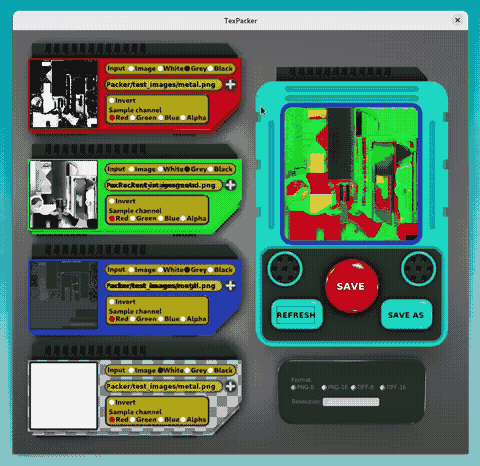

# About:

TexPacker is a program to help 3D artists pack up to four greyscale texture maps into a single image file.

Platforms: TexPacker runs on Linux and Windows

# General Help:

> Currently TexPacker only supports *png* files

## Input

- Image: Uses an external file to pack into the final texture.  
  White: Sets the entire channel color to white.  
  Grey: Sets the entire channel color to grey.  
  Black: Sets the entire output channel color to black.

## Invert

- Inverts the input image.

## Sample Channel:

- Selects which channel of the input image will be used.

# Known Issues:

- Address input doesn’t receive input
- The program doesn’t show alpha on the output preview (**wontfix**)
- Preview texture is not refreshed when *sample channel* is selected

# //TODO

- [ ]`When input type is selected on alpha the program crashes`
- [ ]`Support other file sizes other than 2048*2048 px`
- [ ]`Create a single-channel image to be used as preview`
- [ ]`Check if image is square?`
- [ ]`Command line tools`
- [ ]`Check if images are the same size`
- [ ]`Check for error while opening file without .png`
- [ ]`Configurable output resolution`
- [ ]`Support tiff files (?)`
- [ ]`Implement greying out of the elements that aren't available`
- [x]`Fix crash when <refresh_input_preview> is run`
- [x]`fix white and grey images showing up as black`
- [x]`If alpha sample channel is selected for an image that doesn't have, the program crashes`
- [x]`if alpha image is empty and white save output without alpha`
- [x]`Put comments on the codebase`
- [x]`Define the standard way of accessing elements by the [] operator, it should receive the integers [0-3] inclusive`
- [x]`Turn each color box into a class with a variable color (char or int)`
- [x]`Transform the namespace texpacker into a class`
- [x]`Split <refresh_image()> into <refresh_image()> and <open_image()>`
- [x]`When image is not loaded default to grey`
- [x]`Alpha support`
- [x]`Deglobalise variables`
- [x]`Refresh input image when white/grey/black is selected`
- [x]`Move code from fluid to file`
- [x]`Implement GUI background images`
- [x]`Generate white, grey and black images`
- [x]`Update output image when refresh/save is pressed`
- [x]`Update images during runtime`
- [x]`Save file pop-up`
- [x]`Change to Native File Chooser`

Made with ♡ by [*Arthur J*](http://OvercookedRoach.github.io)